# Update Mail Daemon Client Secret

The HubSpot Service’s ability to send emails from the `tech@terramax.com` email requires extra permission that had to be given by Coordinated. Technically, this permission is granted to the app *registration*, and so for the actual app to use it, it needs to connect via the client secret.

The client secret is like an access token; the registration generates and provides it, and then the app holds onto it as an environmental variable so it can prove it has a right to the permissions listed in the registration. Client Secrets come with expiration dates, and need to be refreshed.

When the HubSpot Service client secret gets close to expiry, you should recieve warning emails about it. If it expires, then the backend HubSpot Service won’t be able to send emails, and the Ordering App and Product Manager App that depend on it will not be able to perform all their functions correctly.

## 1. Find `terramax-hubspot-service-registration` in the Azure Portal

- In the Azure Portal, go to:
  - Entra > App registrations > terramax-hubspot-service-registration

[figure not shown]

## 2. Find the Expired Client Secret

- In the App Registration, you should see a warning with a direct link like this:

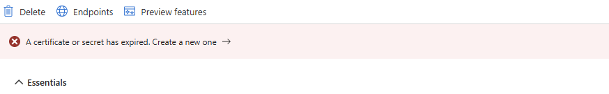

- You can also find the Client Secret by going to:
  - Manage > Certificates & Secrets

## 3. Create New Client Secret

- In *Secrets & Certificates* you should see the expired Secret. You can’t renew it directly, you can to make a new one instead. Click the *New client secret* button

[figure not shown]

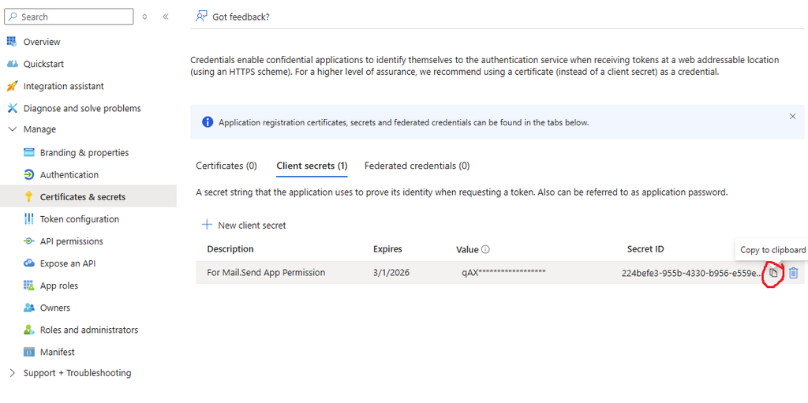

## 4. Add New Secret to `terramax-hubspot-service` in Azure

[figure not shown]

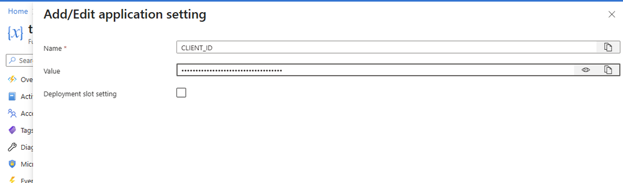

- Click *Apply*

## 5. Add New Secret to Codebase .env File

- Open `hubspot-service` in VSCode and open the `.env` file at the root of the project
- Find the `CLIENT_SECRET` variable in .env, and replace the old value with the new one